# IODS course project

Minna Peralampi

# About the project

Introduction to open data science (IODS) is an university course which goals is to teach students:

- How to use diffrents softwares, like R and GitHub
- How to learn to use more open software tools
- How to apply statistical methods to data

https://github.com/minna4125/IODS-project

# Regression and model validation

#### Reading the data to students2014

students2014 <- read.csv(“learning2014.csv”)

#### Getting a simple overview of the data

head(students2014) str(students2014)

#### There is 7 varriables and 166 observations.

##### The variables are:

1. (*gender*) Gender, male (M) or female (F).
2. (*age*) Age, in years.
3. (*attitude*) Attitude towards statistics.
4. (*deep*) Deep learning, measured by avergagen serie of questions.
5. (*stra*) Strategic learning, measured by averagagen serie of questions.
6. (*surf*) Surface learning, measured by averagagen serie of questions.
7. (*points*) Exam points.

You can get more info of the questions asked in http://www.helsinki.fi/~kvehkala/JYTmooc/JYTOPKYS3-meta.txt

#### Graphical owerlook of the data

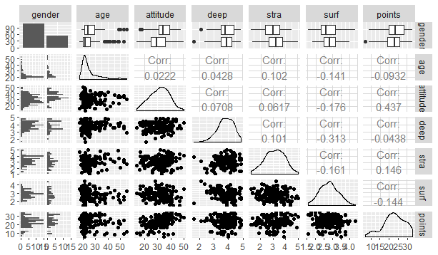

Graphical overlook

###### From the overlook can be seen that there is two times more females than men in the respondents. Majory of the respondents is 20-30 years old. Other variables tend to look approximately like normal distribution.

Most correlation is between deep and surface learning(-0.313), and between attitude and exam points (0.437).

##### Variables that correlate with the exam points the most are attitude, strategic learning and surface learning.

##### Regression model with three explanitory variables for exam points:

my_model <- lm(points ~ attitude + stra + surf, data = students2014)

#### Summary

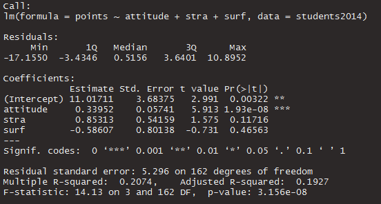

Summary

#### This summary uses two sample t-test. Assumptions in the t-test are that both variables, for example attitude and exam points are normally distributed and independent. This test tells, if explaining variables (surf, stra and attitude) are useful or not. You can see that surf has a large p-value (0.46563) so it is resonable to leave it out in the next step.

##### Summary 2

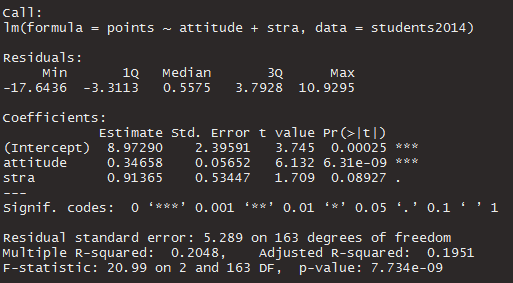

Summary 2

#### From the summary we get that Points ~ 0.34(attitude) + 0.91365(stra).

#### R-squared, is simply that how much of the variance (around the mean) can be explained by the model, 0 being none at all and 1 that all variance is explained. (R-squared is always between 0 and 1.) It is calculated by this formula:

R^2 = 1 - Sum((R[i])^2) / Sum((y[i]- y*)^2),

#### Assumptions of this model are:

1. The errors are normally distributed
2. The errors do not correlate
3. The errors have constant variance
4. The size of a given error doesn’t correlate with the sizes of explaining variables.
5. The model is linear, and not explained by “other shapes”

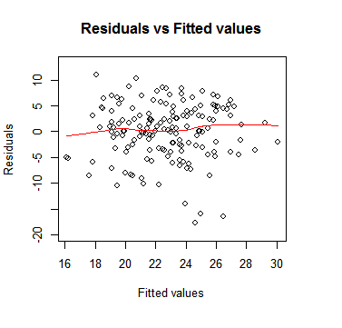

Residuals vs Fitted values plot tells about the assumption number 3. There isn’t any clear pattern in this plot, so it is safe to assume that the errors have a constant variance.It also shows that model’s linearity is possible, because any other pattern isn’t seen (5). Also, the errors are scattered so we can assume that errors do not correlate.

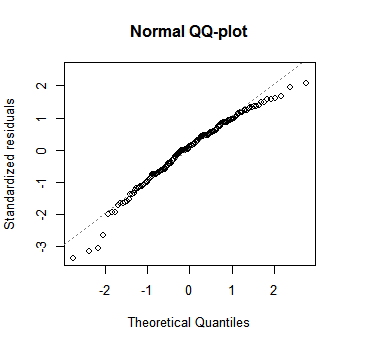

QQ-plot tells us about assumption 1. Dots fit the line so well that it is reasonable to assume that the errors are normally distributed

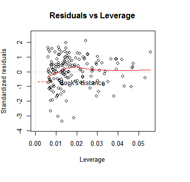

Residuals vs Leverage tells about assumption 4, that the size of an error doesn’t correlate with the size of a variable. There isn’t too noticable pattern, so the assumption is alrigth

# Logistic regression

#### Summary of the data

##### The data is about variables that possibly affect the alcohol usage of the students int portugese and matchematics course.

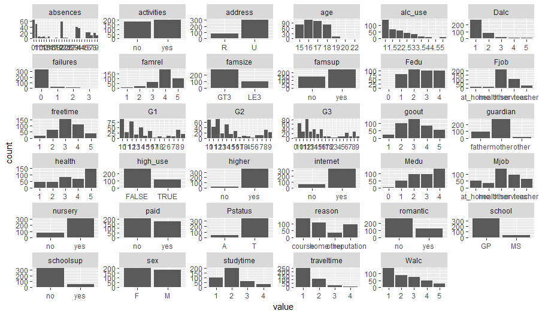

Variables

##### More info about the variables is in https://archive.ics.uci.edu/ml/datasets/STUDENT+ALCOHOL+CONSUMPTION

#### Four variables and the hypothesis of their relatioship with alcohol consumption

##### Variables:

1. Family relationships (famrel, 1-5)
- Better family relationships decrease alcohol consumption
2. Sex, (sex, F/M)
- Males drink more tha females
3. Address (address, urban/rural)
- Urban living decreases alcohol consumption
4. Going out (goout, 1-5)
- Going out increases alcohol consumption

#### Exploration of the variables relationship with high use of alcohol

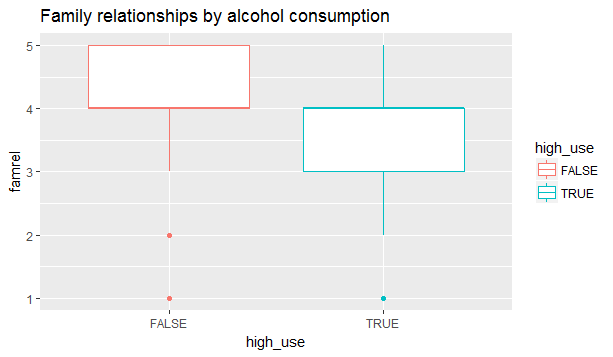

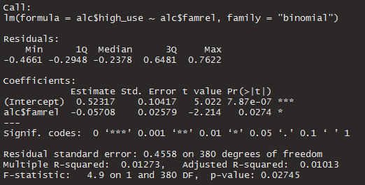

##### Good family relationships correlate negatively with the high use of alcohol.

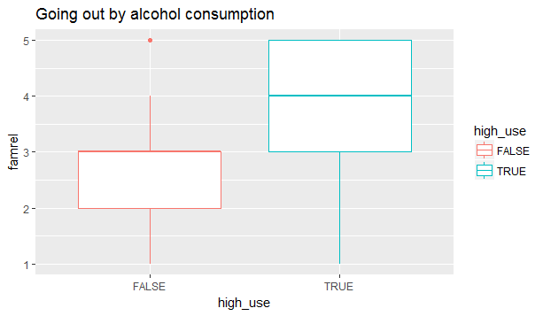

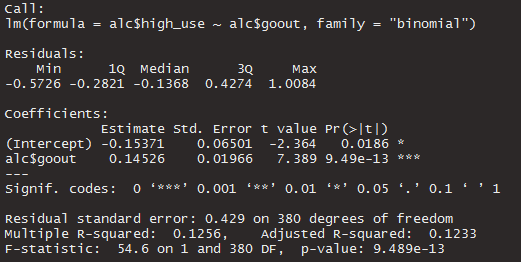

##### Going out correlates with the high consumption of alcohol.

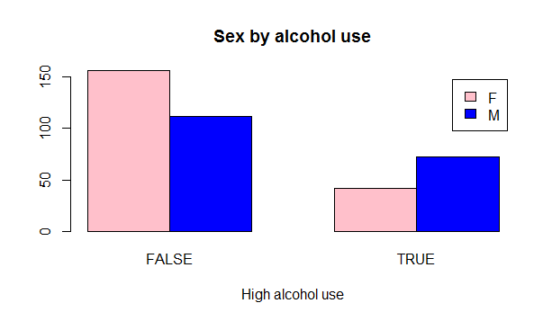

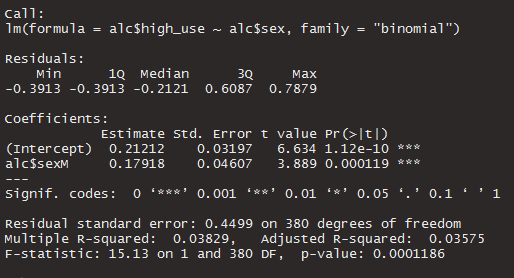

#####There is 198 females and 184 males in the data. There is more men in high use of alcohol group than women. Also bigger portion of men was consuming alcohol than women.

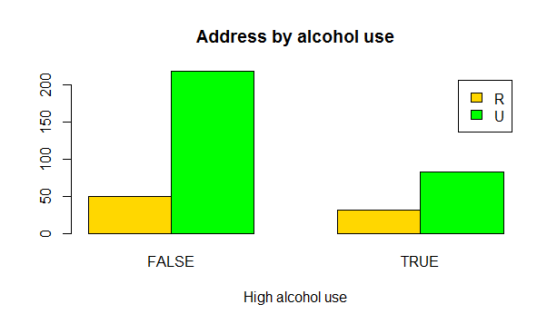

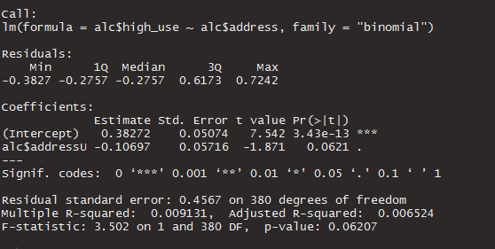

##### Urban living seems to correlate negatively with the high use of alcohol.

### Summary of the fitted model shows that the variables do affect persons use of alcohol. P values suggest that all variables are statistically significant and errors aren’t too bad.

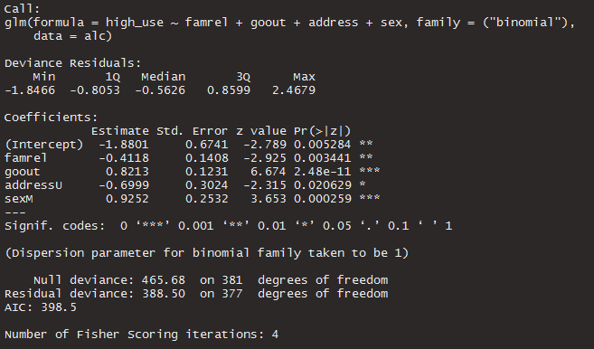

### Coefficients of the model as odds ratios and their confidence intervals shows that familyrelationships and urban address make it less likely to individual to have high alcohol consumption. Going out a lot and being a male makes it more likely to individual to consume a lot of alcohol.

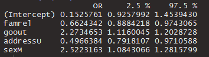

### Inaccutarely classified individuals.

Predictions classifie 12 people falsely to high consume alcohol and 70 people falsely to not high use of alcohol.

| H/P | FALSE | TRUE |
| --- | --- | --- |
| FALSE | 256 | 12 |
| TRUE | 70 | 44 |

# Clustering and classification

##### Explanations for the variables can be found at: https://stat.ethz.ch/R-manual/R-devel/library/MASS/html/Boston.html

##### The data has 506 rows and 14 columns. Numerical summary of the variables looks like this:

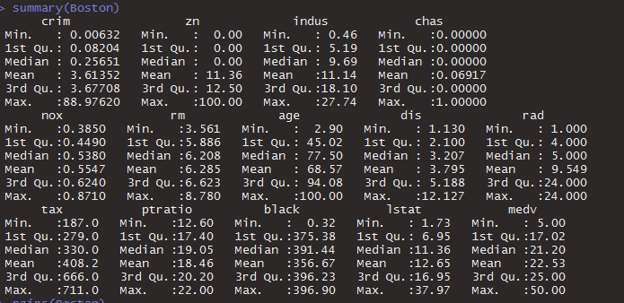

“Summary of the variables”

##### The graphical summary of the variables. The variables aren’t normally distributed.

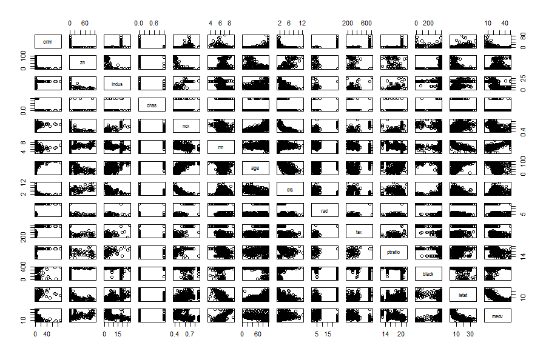

Variable matrix

##### The graphical summary of the correlations of the variables.

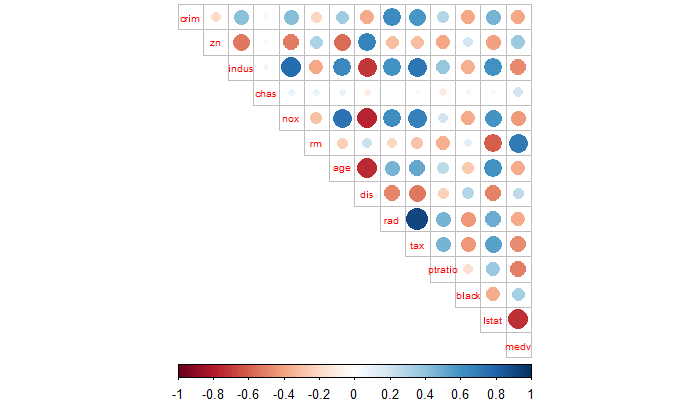

[figure not shown]

##### LDA plot

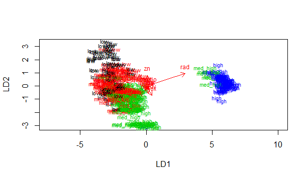

##### Cross tabulations

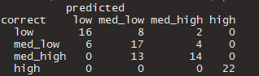

#### Summary of the distances between the observations. The eucliadian method was used.

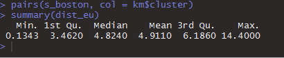

#### Graphical look at the optimal number of clusters

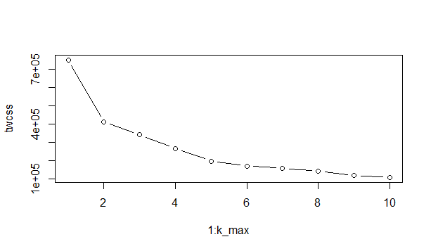

##### Total wcss drops most rapidly from 1 to 2 so we choose 2 clusters for our model.

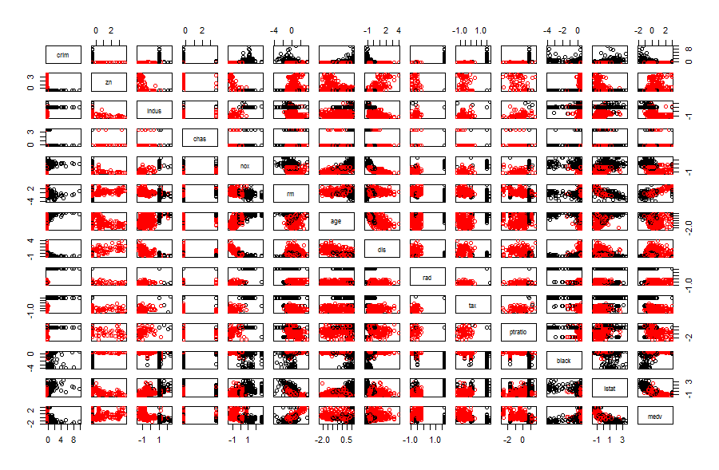

##### Results show that there is some similarity in the data and you can make okay predictions with it.

# Dimensionality reduction techniques

#### About the data

##### The data orgins from United Nations Development program. Variables relate to the measurmenting the well being development of the human in certain countries and areas.The data that is being used has 8 variables and 155 countries.

#### Loading the data and exploring its variables

```
human <- read.csv("human2", header = T, sep = ",", row.names =1)
colnames(human)
dim(human)
summary(human)
```

#### Variables being looked into:

1. Secondary education ratio female/male *edu2.ratio*
2. Labor force ratio female/male *lab.ratio*
3. Life expectancy at birth *life.exp*
4. Excpected years of education *edu.exp*
5. Gross National Income per capita *GNI*
6. Maternal mortality ratio *MMR*
7. Adolescent birth rate *ABR*
8. Precent of females in parliment *PR.parl*

#### Visual reprensation

```
library(GGally)
library(dplyr)
library(corrplot)

ggpairs(human)

cor(human)%>%corrplot()
```

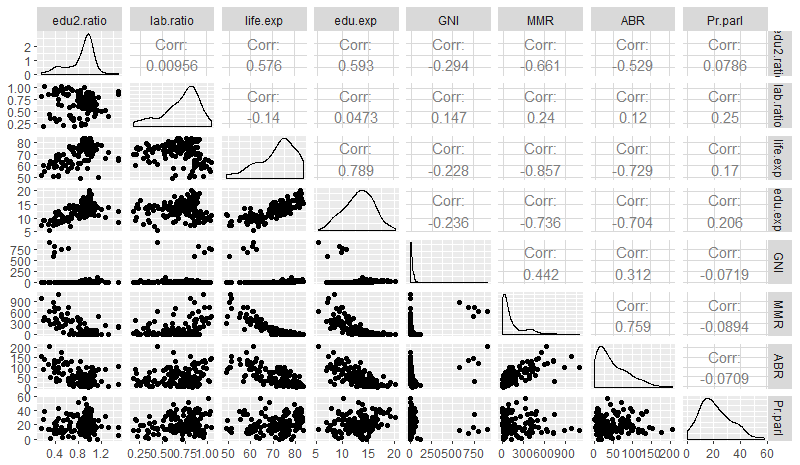

#### Distributions of the variables

##### Gross National Income per capita (GNI) and Maternal Mortality Ratio (MMR) are leaning strongly towards the smaller values. Adolescent birt rate (ABR) is also quite small in most of the countries. Other variables are more evenly distributed with a peak in the middle values.

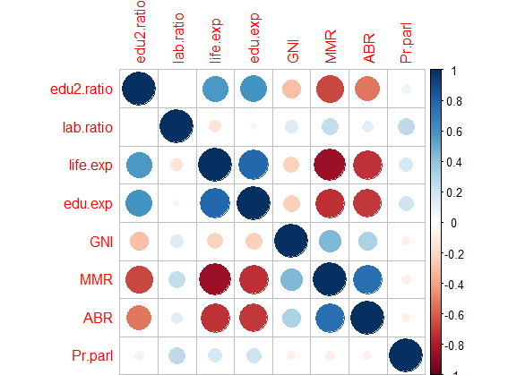

#### Relationships between the variables

##### There is strong negative correlation between life expectancy (life.exp) and MMR.Life.exp correlates also negatively between ABR. Life.exp and edu.exp correlate positevly with each other. Edu.exp correlates negatively with MMR and ABR also.

### PCA on non-standardized data

```
summary(human)
pca_human <- prcomp(human)
biplot(pca_human, choices = 1:2)
```

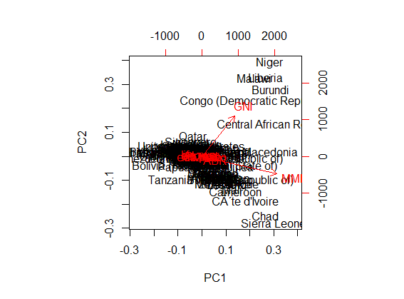

### PCA on standardized data

```
 s_human <- scale(human)
 summary(s_human)
 spca_human <- prcomp(s_human)
 biplot(spca_human, choices = 1:2)
```

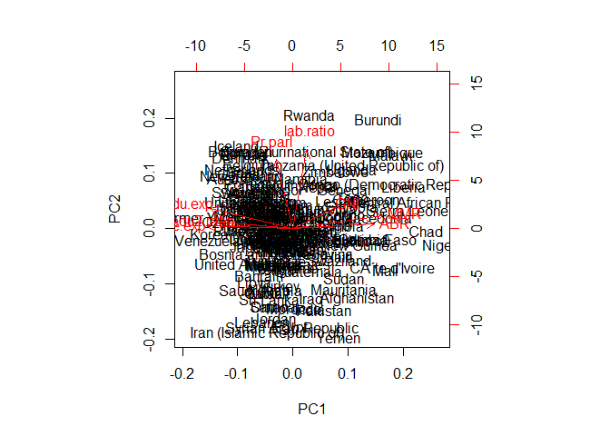

#### Analysis of the PCA

##### The results differ a lot between standardized and non-standardized data. Frist one doesn’t really tell anything,

On the second one we can see that MMR and ABR correlate positevly with each other and negatively with life excpectancy and education excpectancy.Young mothers are more likely to die during pregnancy and child birth than older mothers. Also, young women are more likely to become pregnant in the countries that have lower education and life expectancy because of lack of possibilities to choose otherwise and little to none sexual education.

### The tea dataset and Multiple Correspondence Analysis

[output not shown]

### Structure of the data is a data frame with 300 observations and 36 factor variables.

#### Six variables to look closer at

```
# column names to keep in the dataset
keep_columns <- c("Tea", "How", "breakfast", "SPC", "friendliness","evening" )

# select the 'keep_columns' to create a new dataset
tea_time <- select(tea, one_of(keep_columns))

# look at the summaries and structure of the data
summary(tea_time)
str(tea_time)

# visualize the dataset
gather(tea_time) %>% ggplot(aes(value)) + facet_wrap("key", scales = "free") + geom_bar()+theme(axis.text.x = element_text(angle = 45, hjust = 1, size = 8))
```

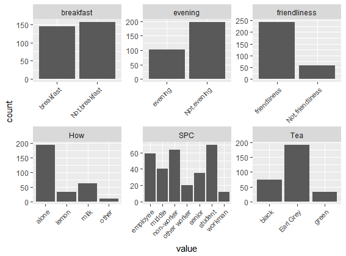

```
# multiple correspondence analysis
mca <- FactoMineR::MCA(tea_time, graph = FALSE)

# summary of the model
summary(mca)

# visualize MCA
plot(mca, habillage = "quali", invisible=c("ind"))
```

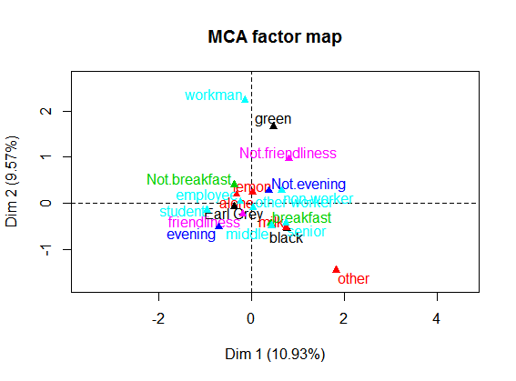

#### Black tea and milk are similar variables. Other similiar variables to them are breakfest and middle/senior possition as a worker. Workman, other than worker and green tea are diffrent from all the other variables. We could say from this anlysis that people who drink black tea drink it more likely with milk than people who drink green tea.